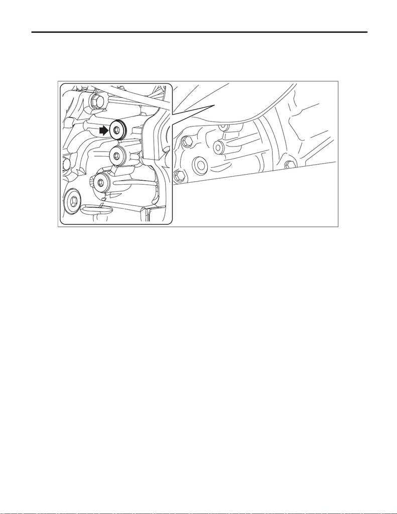

Transfer Clutch Pressure Test

CONTINUOUSLY VARIABLE TRANSMISSION

9. Transfer Clutch Pressure Test

A: INSPECTION

1) Lift up the vehicle.

2) Remove the test plug.

AT-07752

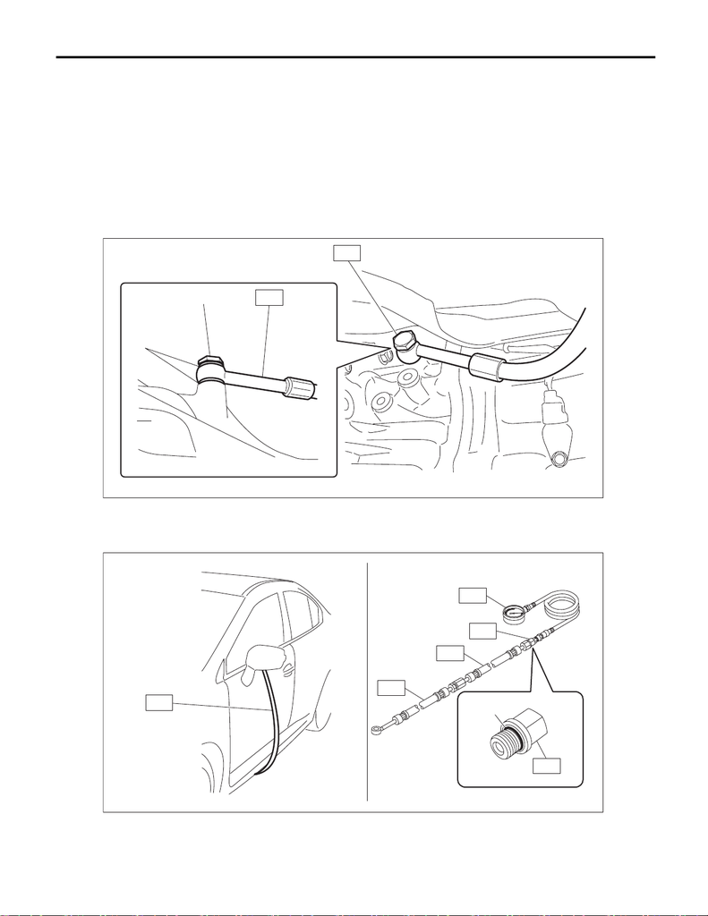

CVT(TR690)-53

Transfer Clutch Pressure Test

CONTINUOUSLY VARIABLE TRANSMISSION

3) Set the ST1, ST2, ST3 and ST4 to the transmission.

CAUTION:

Be careful when setting tools so that the hoses do not touch the exhaust pipes.

NOTE:

• Use ST1 ADAPTER HOSE B with genuine union screw (part No. 801914010) and gasket (part No.

803914060) attached.

• Use ST3 PRESSURE GAUGE ADAPTER with genuine O-ring (part No. 806911080) attached.

ST1 34099AC020 ADAPTER HOSE B

ST2 34099AC010 ADAPTER HOSE A

ST3 18681AA000 PRESSURE GAUGE ADAPTER

ST4 498575400 OIL PRESSURE GAUGE ASSY

(A) Gasket (genuine part)

(B) Union screw (genuine part)

(A) O-ring (genuine part)

CVT00486

(A)

ST1

ST1

CVT00487

ST4

ST4

ST2

ST3

ST1

ST3

(A)

[figure not shown]

CVT(TR690)-54

Transfer Clutch Pressure Test

CONTINUOUSLY VARIABLE TRANSMISSION

4) Lower the vehicle.

5) Connect the Subaru Select Monitor to the data link connector and read the current data.

Secondary Pressure (Line Pressure) Test.>

NOTE:

If oil pressure is not produced or it does not change, the control valve body may be malfunctioning.

7) Lift up the vehicle.

8) Remove the ST.

Range position

ON

Duty ratio

(%)

Accelerator pedal opening angle

(%)

Standard transfer clutch pressure

2

, psi)

D

95 — 100 Fully opened (100)

1,000 — 1,200

(10.2 — 12.2,

145 — 174)

60 Adjust ON Duty ratio to 60%.

400 — 700

(4.1 — 7.1,

58 — 102)

0 Fully closed (0) —

N or P 0 Fully closed (0) 0

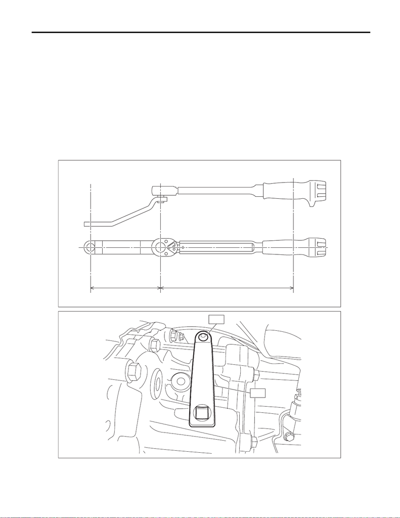

CVT(TR690)-55

Transfer Clutch Pressure Test

CONTINUOUSLY VARIABLE TRANSMISSION

9) Install the test plug using ST1 and ST2.

NOTE:

• Use new O-rings.

• Apply CVTF to the O-rings.

• Tighten the test plug while directly aligning ST2 and torque wrench.

ST1 18270AA040 SOCKET

Using the following formula, calculate the tightening torque for a torque wrench.

T2 = L2/(L1 + L2) × T1

T1: 25 N·m (2.5 kgf-m, 18.4 ft-lb)

L1: ST2 length 0.1 m (3.94 in) (a)

L2: Torque wrench length (b) m (in)

[Required torque setting]

T2: Tightening torque: N·m (kgf-m, ft-lb)

10) Lower the vehicle.

CVT00538

(b)(a)

CVT00537

ST1

ST2